# Would Australians accept technological interventions for a large-scale ecological restoration?

Yuwan Malakar

Land and Water

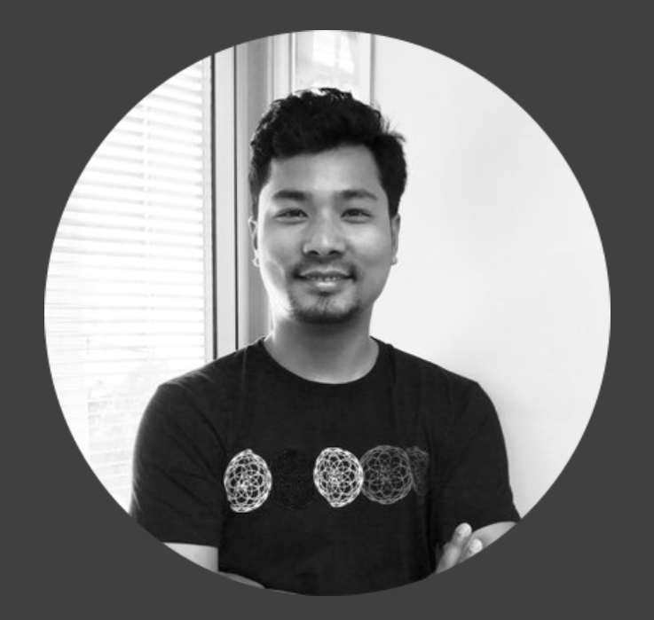

# Introduction

I am a *postdoctoral research fellow* in the **Responsible Innovation FSP**. My backgroud in social science. Before Data School, I thought I could write my own code, but that was not true. I rather used to copy codes from the web. I work on both qualitative and quantitative data. It is exciting to learn that data visualisation is possible not only from quantitative, but also from qualitative data.

# My Project

In this project, I am studying how people’s perception influences their acceptance of technological interventions for a large-scale restoration. The data for this study comes from a public survey, conducted in 2018. The survey was designed to examine Australian public’s perception. There are a total of six predictors and one outcome variable. I employed the Structural Equation Modeling (SEM) to test the following hyptheses.

1. Predictor 1 and 6 predict Outcome.
2. Predictor 2, 3, 4, and 5 predict Predictor 6

## Preliminary results

**Plots from R**

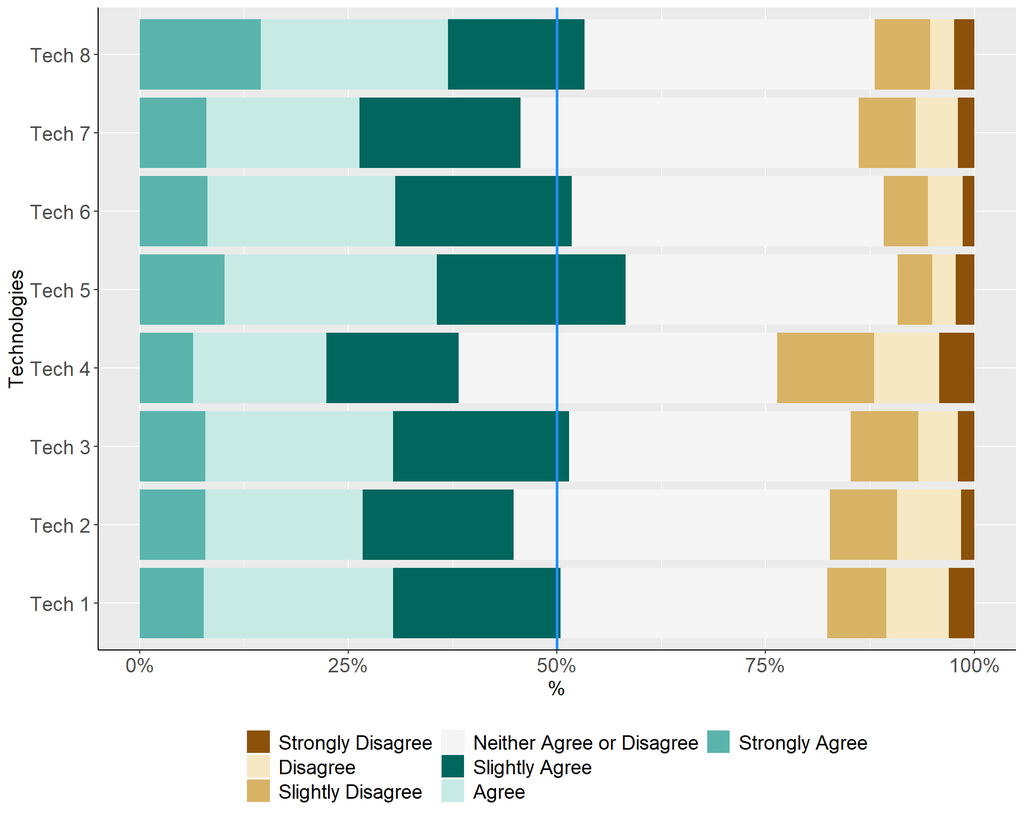

Figure 1: Participants’ response on each technology

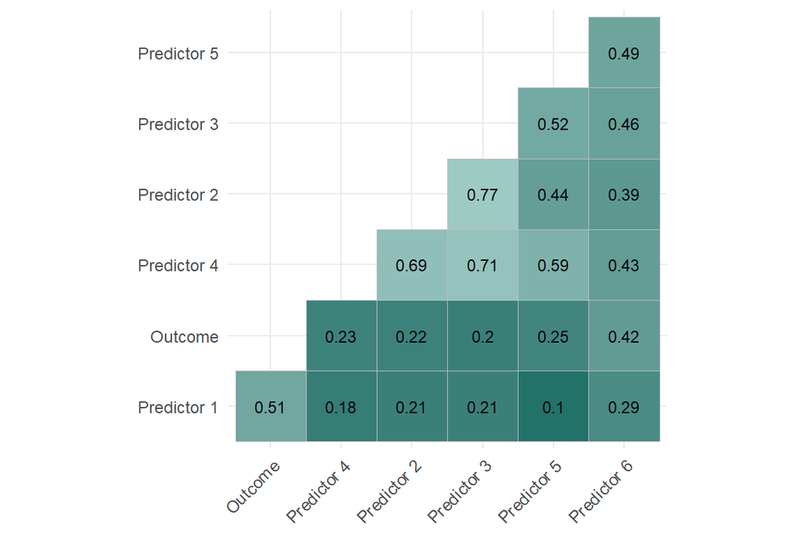

Figure 2: Correlations between the study variables

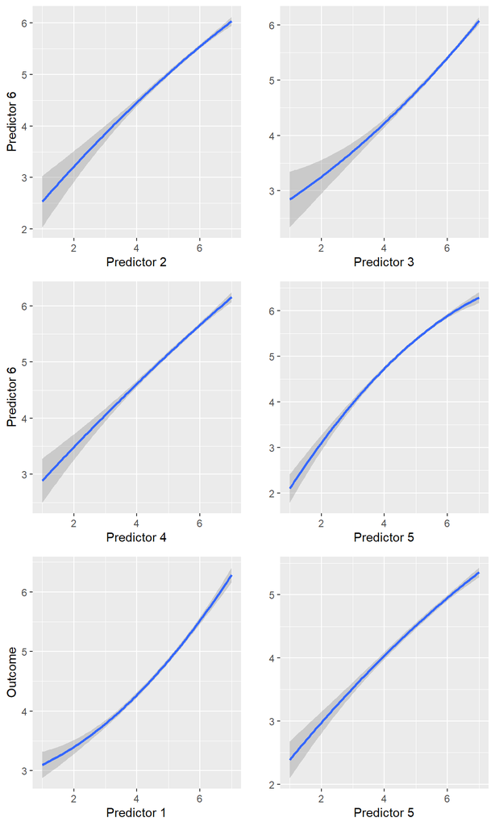

Figure 3: Relationships between dependent and independent variables

**Table**

| Independent variables | Dependent variables | Beta | pvalue |
| --- | --- | --- | --- |
| Outcome | Predictor 6 | 0.2936675 | 0.0000000 |
| Outcome | Predictor 1 | 0.4542194 | 0.0000000 |
| Predictor 6 | Predictor 5 | 0.3751524 | 0.0000000 |
| Predictor 6 | Predictor 1 | 0.1816208 | 0.0000000 |
| Predictor 6 | Predictor 2 | 0.0121496 | 0.6708499 |
| Predictor 6 | Predictor 3 | 0.1946816 | 0.0000000 |
| Predictor 6 | Predictor 4 | 0.0220048 | 0.3779884 |

[interactive chart not shown]

Figure 4: Relationships between the predictors and the outcome variable

# My Digital Toolbox

My original data sets were in .dta format. I used the **readstata13** to import the data into R. All the other steps were performed within R. The **tidyverse** package was especially beneficial to tidy up my data. Additionally, I used the **lavaan** packaage to run SEM. For the correlation plot, I used the **ggcorrplot** package (Figure 2). The **ggpubr** packaged helped to combine the regression plots (Figure 3). Finally, to plot the relationships between the outcome and predicting variables, I used **networkD3** package (Figure 4).

# My time went …

I think running the SEM model and visualising the model using *netwrodD3* was the most challenging part. It was the first time that I visualised an SEM model using this package.

# Next steps

In relation to this project, the next step for me would be to develop it as a manuscript for a journal submission (fingers crossed). Regarding data analysis and visualisation, I will keep exploring and be open to challenge my comfort zone.

# My Data School Experience

In a nutshell, it was an amazing experience. The efforts and dedications that our instructors and helpers have put were simply outstanding. I thoroughly enjoyed all the challenges posted to us on Microsoft Teams. I appreciate the work behind the screen to put things in place for us to use, e.g. notes, attendance, files, data, and images. Finally, I love working on data. I will be using my skills a lot in my project.